# GSM3528804_QC

Jacopo Umberto Verga

2022-11-21

# Quality control and filtering results from cellranger

## Sample info and environment setup

# PRJNA511584

- Bioproject: PRJNA511584
- [Article](https://doi.org/10.1038/s43018-020-0053-3): Single-cell RNA sequencing reveals compromised immune microenvironment in precursor stages of multiple myeloma
- Journal: Nature Cancer
- Samples: 23, MGUS, SMM or PMM, CD138- and CD45+
  - Data format: 10x matrix
- Technology: 10x Chromium
- Patient GSM3528804: SMM4 CD138-

```r
setwd("/media/jacopo/Elements/re_align/MM/PRJNA511584/GSM3528804_SMMh-4.138N.filtered_gene_bc_matrices/")
# Load the libraries (from Sarah script + biomart)
library(tidyverse) # packages for data wrangling, visualization etc
library(Seurat) # scRNA-Seq analysis package
library(clustree) # plot of clustering tree
library(ggsignif) # Enrich your 'ggplots' with group-wise comparisons
library(clusterProfiler) #The package implements methods to analyze and visualize functional profiles of gene and gene clusters.
library(org.Hs.eg.db) # Human annotation package neede for clusterProfiler
library(ggrepel) # extra geoms for ggplo2
library(patchwork) #multiplots
library(reticulate)
```

## Load and process cellranger data

Load and do the QC for the cellranger data

```r
#list.files(".")
```

```r
dat <- Read10X(data.dir = "./filtered_gene_bc_matrices/GRCh38/")
dat <- CreateSeuratObject(dat) # Create the seurat object from the 10x data
kb.initial <- dat@assays[["RNA"]]@counts@Dim[[2]]
cat("Initial number of cells:", kb.initial,
    "\nNumber of genes:",  dat@assays[["RNA"]]@counts@Dim[[1]])
```

```
## Initial number of cells: 2300
## Number of genes: 33694
```

## Quality Control

Empty cells were already filtered, check for % mt RNA and death markers:

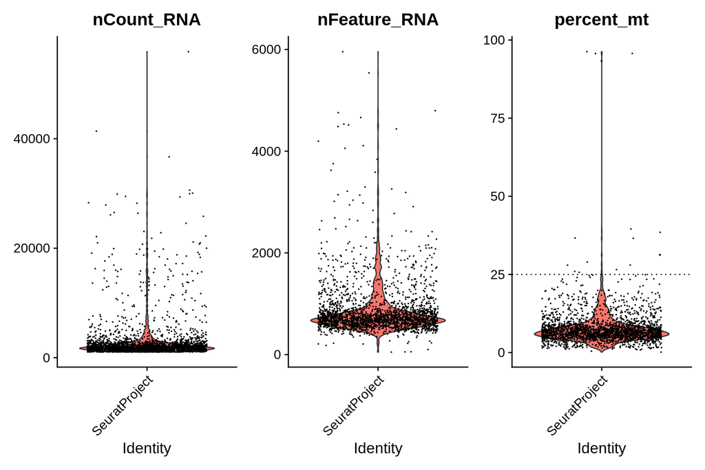

```r
# first calculate the mitochondrial percentage for each cell
dat$percent_mt <- PercentageFeatureSet(dat, pattern="^MT.")
# make violin plots
mt_rna = 25
max_counts =30000



# Check some feature-feature relationships
# % mt RNA vs n Counts, n Features vs n Counts
# Check some feature-feature relationships
# % mt RNA vs n Counts, n Features vs n Counts
VlnPlot(dat, features = c("nCount_RNA", "nFeature_RNA", "percent_mt"))  + geom_hline(yintercept=mt_rna, linetype = "dotted")
```

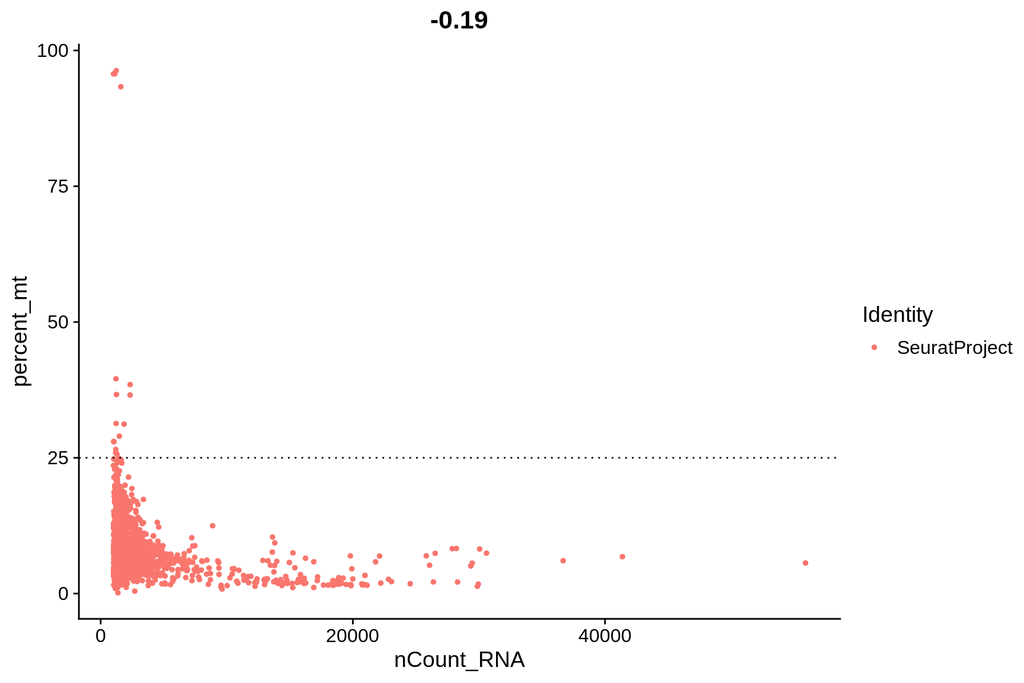

```r
plot1 <- FeatureScatter(dat, feature1 = "nCount_RNA", feature2 = "percent_mt")
plot1 <- plot1 + geom_hline(yintercept=mt_rna, linetype = "dotted")
plot2 <- FeatureScatter(dat, feature1 = "nCount_RNA", feature2 = "nFeature_RNA")
plot2 <- plot2 + geom_vline(xintercept = max_counts, linetype = "dotted")
plot1
```

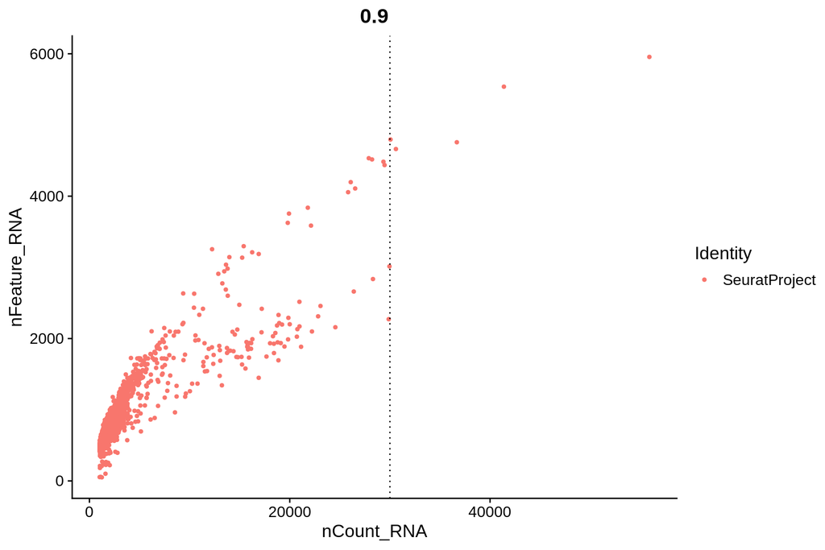

```
##  cells retained by mt RNA content ( 25 %): 2284
##  percentage of retained cells: 99.3 %
```

```
## cells retained by counts ( 30000 ): 2279
##  percentage of retained cells: 99.09 %
```

```r
plot2
```

Check the distribution of the cells with low counts and control death markers:

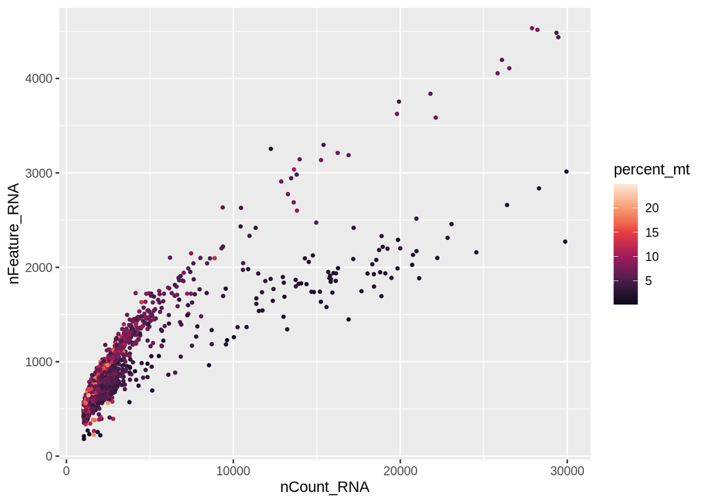

```r
dir.create("result")
saveRDS(dat, file = "./result/GSM3528804_clean_QC.Rds")
```

## Feature selection

```r
#Normalize
dat <- NormalizeData(dat)
# Find the first 4000 variabe features
dat <- FindVariableFeatures(dat, selection.method = "vst", nfeatures = 4000)
```

## Data scaling

Set mean expression to 0 and variance across 1 to avoid highly expressed genes drive the forwarding analyses. Since negative expression is meaningless, scaled data are useful only for UMAP and clustering

```r
# scale data, the scaled data are saved in:
# dat[["RNA"]]@scale.data

all.genes <- rownames(dat)

dat <- ScaleData(dat, vars.to.regress = c("percent_mt","nCount_RNA"))
```

## Dimensionality reduction

```r
dat <- RunPCA(dat, features = VariableFeatures(object = dat), verbose = F, seed.use = 1)
print(dat[["pca"]], dims = 1:5, nfeatures = 5)
```

```
## PC_ 1
## Positive:  IGHA2, IGKC, IGHA1, DERL3, TNFRSF17
## Negative:  AIF1, HLA-DRA, LST1, HLA-DRB1, LYZ
## PC_ 2
## Positive:  KIAA0101, TYMS, CENPU, KLF1, GATA1
## Negative:  CST3, CTSS, LYZ, FCN1, LST1
## PC_ 3
## Positive:  RPL10, RPS18, RPS3A, RPS6, RPS2
## Negative:  HBD, SLC4A1, HBM, AHSP, HEMGN
## PC_ 4
## Positive:  S100A6, IL32, GNLY, S100A11, KLRB1
## Negative:  CD79A, TCL1A, VPREB3, SPIB, MS4A1
## PC_ 5
## Positive:  GZMB, GNLY, KLRD1, CLIC3, SRGN
## Negative:  LTB, MS4A1, CD79A, IGHD, HLA-DQA1
```

## UMAP

UMAP is a graph-based method of clustering. The first step in this process is to construct a KNN graph based on the euclidean distance in PCA space:

```r
dat <- FindNeighbors(dat, dims = 1:20)
```

The graph now can be used as input for the function `runUMAP()`

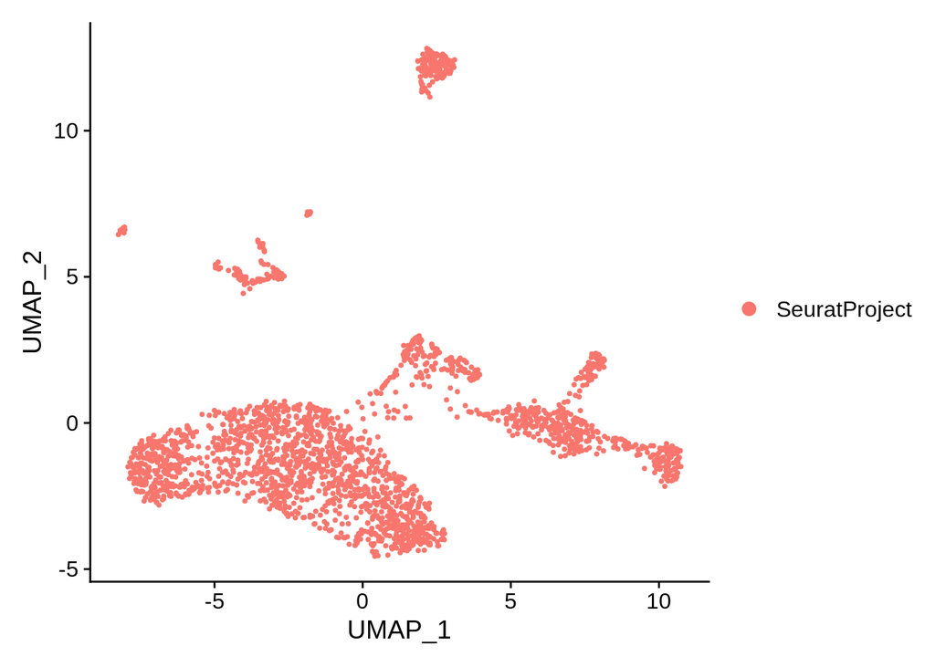

```r
dat <- RunUMAP(dat, dims = 1:20, seed.use = 1)
DimPlot(dat, reduction = 'umap', seed = 1)
```

## Final plots:

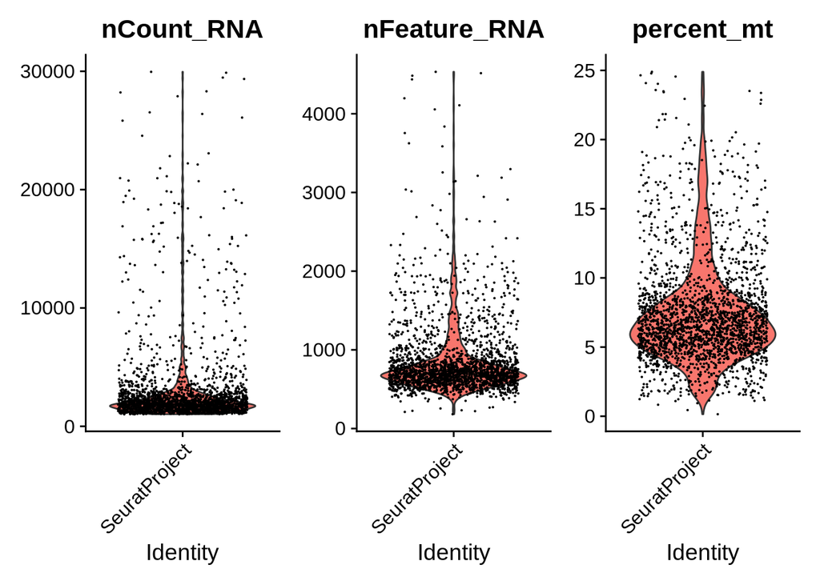

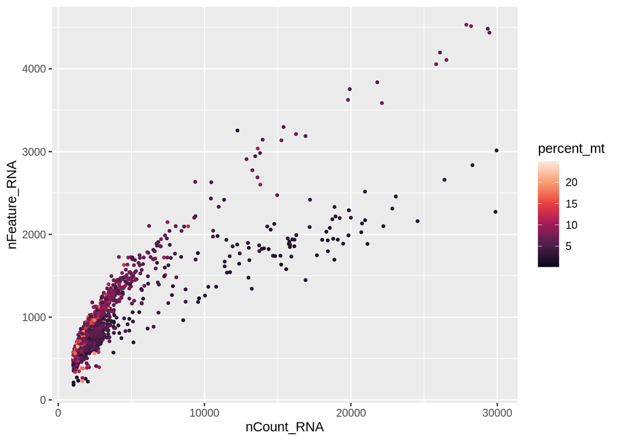

```
## QC metrics
```

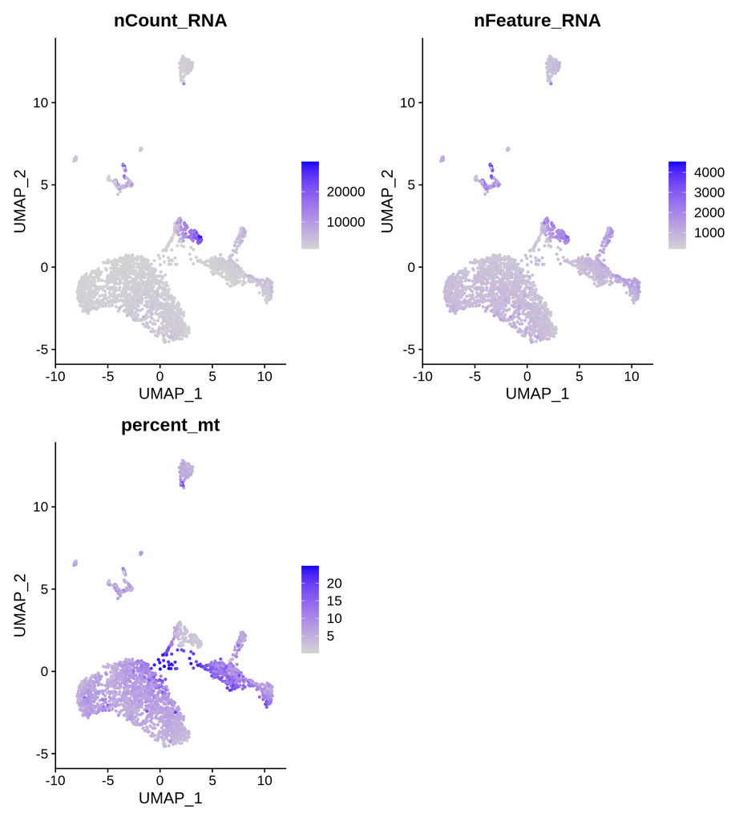

```
## markers
```

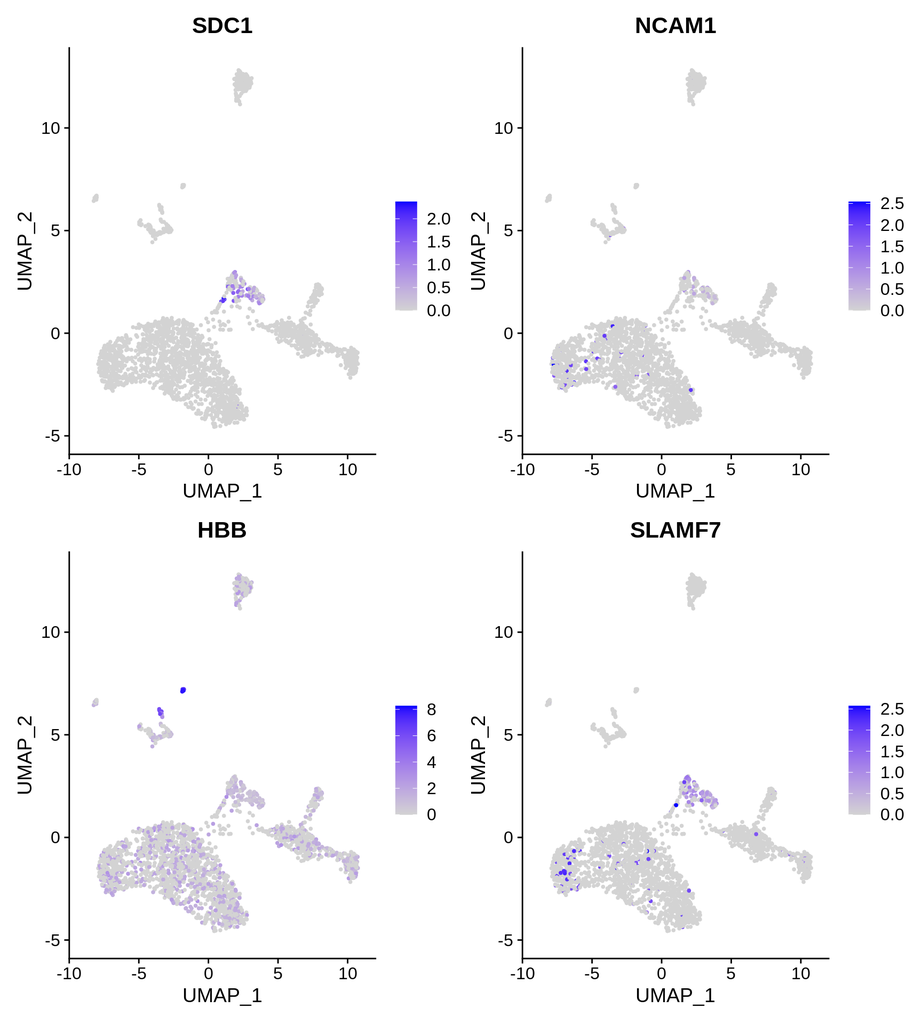